# RNA-Seq Data Analysis with GEO

Selda Akdal

2026-04-11

# RNA-Seq Data Analysis with GEO

## Installing and Loading Packages

Install required packages.

```r
#if (!require("BiocManager", quietly = TRUE))
#  install.packages("BiocManager")

#BiocManager::install("org.Hs.eg.db")

#  org.Sc.sgd.db is installed from Bioconductor because it is not available on CRAN.

#if (!require("BiocManager", quietly = TRUE))
#  install.packages("BiocManager")

#BiocManager::install("clusterProfiler")

# clusterProfiler is installed from Bioconductor because it is not available on CRAN.

#if (!require("BiocManager", quietly = TRUE))
#  install.packages("BiocManager")

#BiocManager::install("pathview")

# pathview is installed from Bioconductor because it is not available on CRAN.

#if (!require("BiocManager", quietly = TRUE))
#  install.packages("BiocManager")

#BiocManager::install("EnhancedVolcano")

# EnhancedVolcano is installed from Bioconductor because it is not available on CRAN.

#if (!require("BiocManager", quietly = TRUE))
#  install.packages("BiocManager")

#BiocManager::install("DESeq2")

# DESeq2 is installed from Bioconductor because it is not available on CRAN.
#install.packages("tidyverse")
#install.packages("pheatmap")
```

Load required libraries.

```r
library(DESeq2)
library(org.Hs.eg.db)
```

```r
library(pheatmap)
library(tidyverse)
library(clusterProfiler)
library(pathview)
library(EnhancedVolcano)
```

DESeq2 is used for differential expression analysis. org.Hs.eg.db provides Homo sapiens gene annotations.  
pheatmap is used for heatmap visualization. tidyverse is used for data manipulation. clusterProfiler and pathview are used for enrichment analysis.

## Loading Data

Read gene count data from a text file.

```r
count_data <- read.delim("GSE165308_gene_count.txt", row.names = 1)
```

Select the first six columns containing count data.

```r
count_data <- dplyr::select(count_data, 1:6 )
```

## Defining Experimental Conditions

Create sample metadata for DESeq2 analysis.

```r
sample_info <- data.frame(condition=c( "control", "control", "control", "knockout", "knockout", "knockout"))

rownames(sample_info) <- colnames(count_data)
```

Match sample names between metadata and count matrix.

### Checking Data Compatibility

Verify that sample metadata and count matrix are aligned.

```r
all(rownames(sample_info)==colnames(count_data))
```

```
## [1] TRUE
```

## Creating DESeqDataSet

Create DESeqDataSet object for DESeq2 analysis.

```r
dds <- DESeqDataSetFromMatrix(countData = count_data,
                              colData = sample_info,
                              design = ~condition)
dds
```

```
## class: DESeqDataSet
## dim: 58735 6
## metadata(1): version
## assays(1): counts
## rownames(58735): ENSG00000000003 ENSG00000000005 ... ENSG00000285993
##   ENSG00000285994
## rowData names(0):
## colnames(6): WT_1 WT_2 ... GFI1KO_2 GFI1KO_3
## colData names(1): condition
```

### Filtering Low Count Genes

Remove genes with low read counts.

```r
keep <- rowSums(counts(dds)) >= 10
dds <- dds[keep,]
```

### Setting Reference Level

Set control as the reference condition.

```r
dds$condition <- relevel(dds$condition, ref = "control")
```

## Running Differential Expression Analysis

Run DESeq2 differential expression analysis.

```r
dds <- DESeq(dds)
```

Extract differential expression results.

```r
res <- results(dds)

res
```

```
## log2 fold change (MLE): condition knockout vs control
## Wald test p-value: condition knockout vs control
## DataFrame with 23634 rows and 6 columns
##                  baseMean log2FoldChange     lfcSE       stat      pvalue
##                 <numeric>      <numeric> <numeric>  <numeric>   <numeric>
## ENSG00000000003  1060.342     -0.6347826 0.0643263   -9.86817 5.71988e-23
## ENSG00000000419   809.044     -0.2922123 0.0722946   -4.04197 5.30045e-05
## ENSG00000000457   350.224     -0.2432322 0.1028904   -2.36399 1.80792e-02
## ENSG00000000460   596.662     -0.3423070 0.0794801   -4.30682 1.65615e-05
## ENSG00000001036  1277.571      0.0651606 0.0578968    1.12546 2.60394e-01
## ...                   ...            ...       ...        ...         ...
## ENSG00000285976  55.22985       0.480585  0.252164  1.9058425   0.0566706
## ENSG00000285979  92.08289      -0.272892  0.203114 -1.3435441   0.1790959
## ENSG00000285982   1.96259      -0.133274  2.765254 -0.0481961   0.9615600
## ENSG00000285991   4.93501       0.226583  0.857836  0.2641326   0.7916777
## ENSG00000285994   1.66968      -1.372286  1.677187 -0.8182067   0.4132392
##                        padj
##                   <numeric>
## ENSG00000000003 4.92051e-22
## ENSG00000000419 1.53367e-04
## ENSG00000000457 3.69255e-02
## ENSG00000000460 5.04986e-05
## ENSG00000001036 3.72210e-01
## ...                     ...
## ENSG00000285976    0.102832
## ENSG00000285979    0.275894
## ENSG00000285982    0.974384
## ENSG00000285991    0.855190
## ENSG00000285994    0.535170
```

## PCA Plot Generation

Perform variance stabilizing transformation (VST).

```r
vstdata <- vst(dds, blind = F)
```

Generate PCA plot using transformed data.

```
## using ntop=500 top features by variance
```

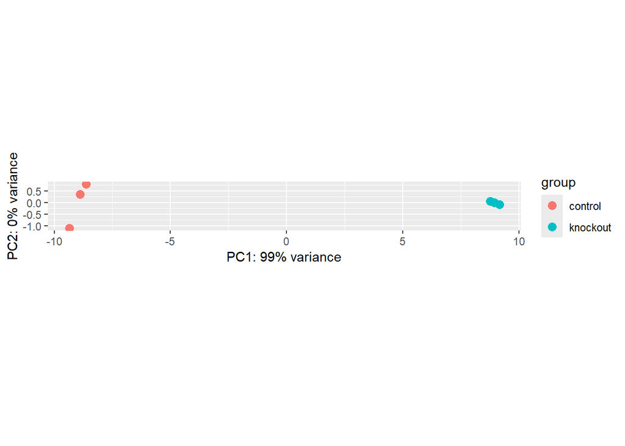

```r
plotPCA(vstdata, intgroup="condition")
```

### Creating MA Plot

Generate MA plot for differential expression results.

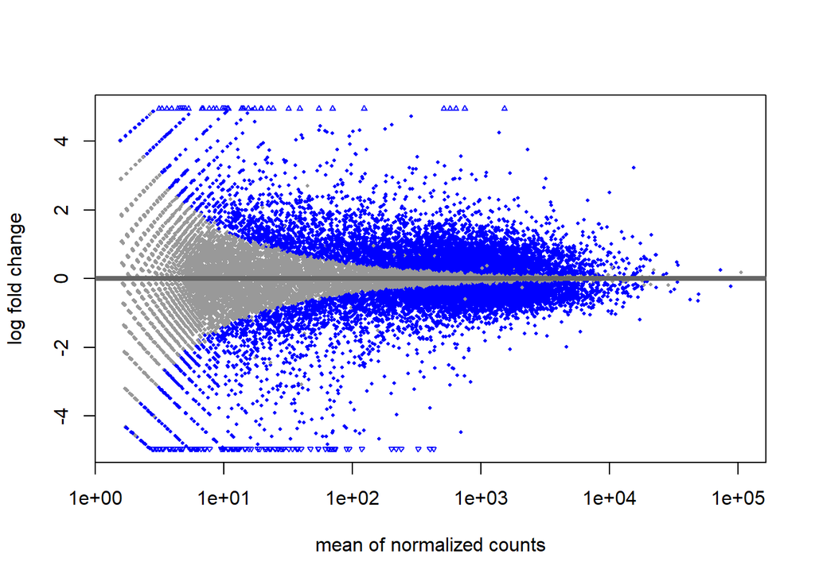

```r
plotMA(dds, alpha=0.05)
```

## Converting Results into Dataframe

Convert DESeq2 results into a dataframe.

```r
res_df <- as.data.frame(res)
```

Label significantly differentially expressed genes.

```r
res_df$significant <- ifelse( res_df$padj < 0.05, "yes", "no")
```

### Designing MA Plot with ggplot2

Visualize differential expression results using ggplot2.

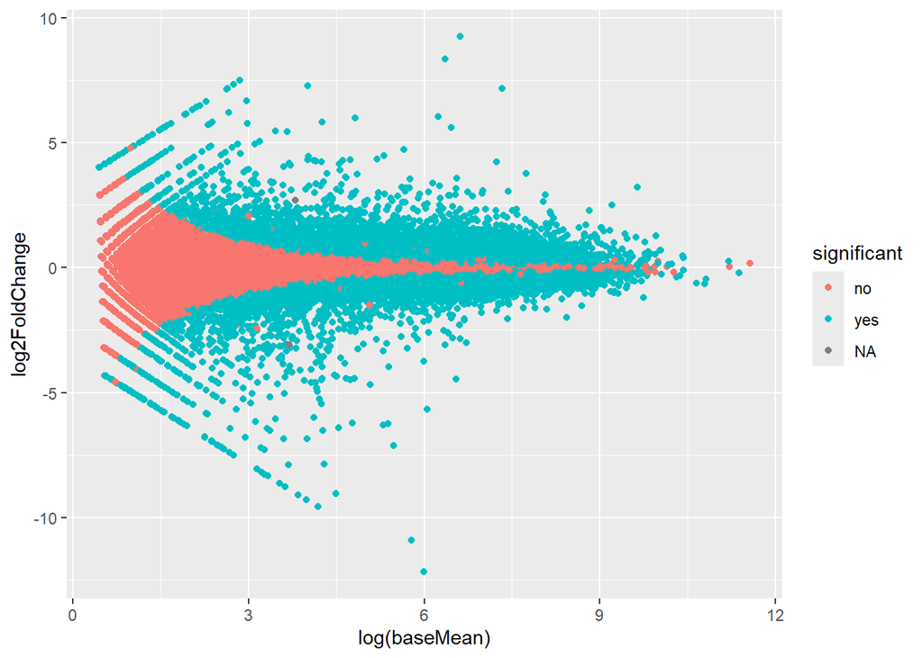

```r
ggplot(res_df, aes(log(baseMean), log2FoldChange, color=significant)) +
  geom_point()
```

### Retrieving Gene Symbols

Map ENSEMBL IDs to gene symbols using org.Hs.eg.db.

```r
res_df$symbol <- mapIds(org.Hs.eg.db,
                        keys = rownames(res_df),
                        keytype = "ENSEMBL",
                        column = "SYMBOL")
```

### Enhanced Volcano Plot

Generate volcano plot using EnhancedVolcano.

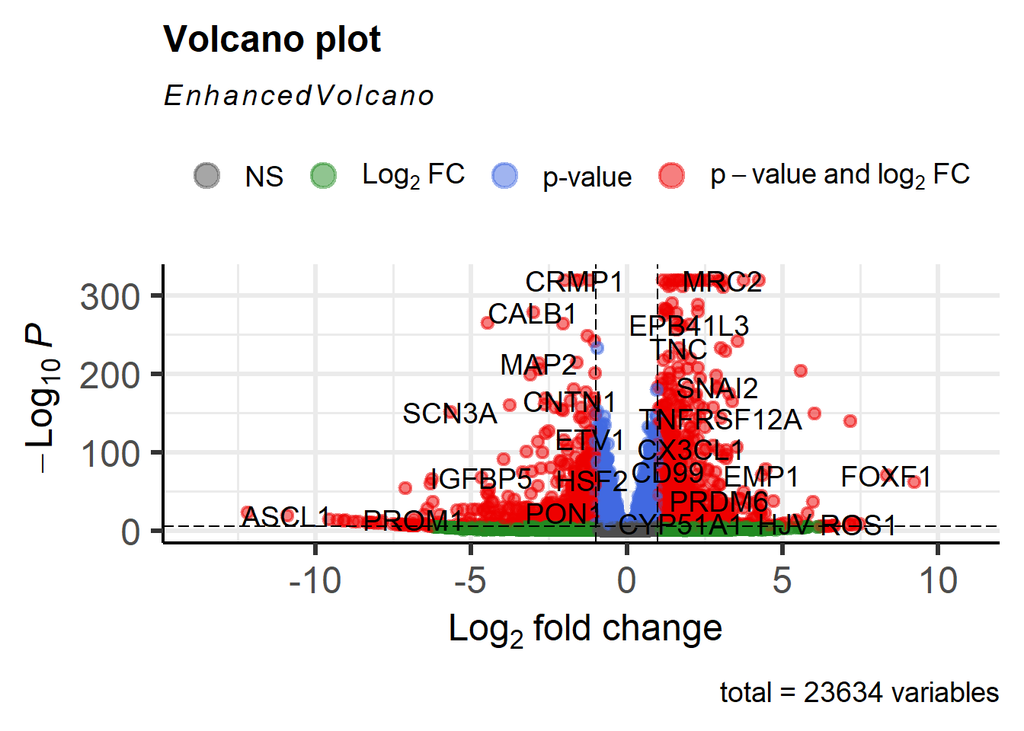

```r
EnhancedVolcano(res_df, x="log2FoldChange", y="padj", lab = res_df$symbol)
```

## Obtaining Normalized Counts

Extract normalized count values.

```r
normalized_counts <- counts(dds, normalized=T)
```

Convert normalized counts into a dataframe.

```r
normalized_counts <- as.data.frame(normalized_counts)
```

Merge normalized counts with DESeq2 results.

```r
res_normalize <- merge(res_df, normalized_counts, by=0)
```

Select top 20 significant genes. Remove missing values and sort genes by significance.

```r
top_20 <- res_normalize %>%
  drop_na(symbol) %>%
  filter(padj < 0.05 & abs(log2FoldChange) > 1) %>%
  arrange(padj) %>%
  select(9:15) %>%
  head(20)
```

Assign gene symbols as row names.

```r
rownames(top_20) <- top_20$symbol
top_20$symbol <- NULL
```

Generate heatmap using log2-transformed normalized counts.

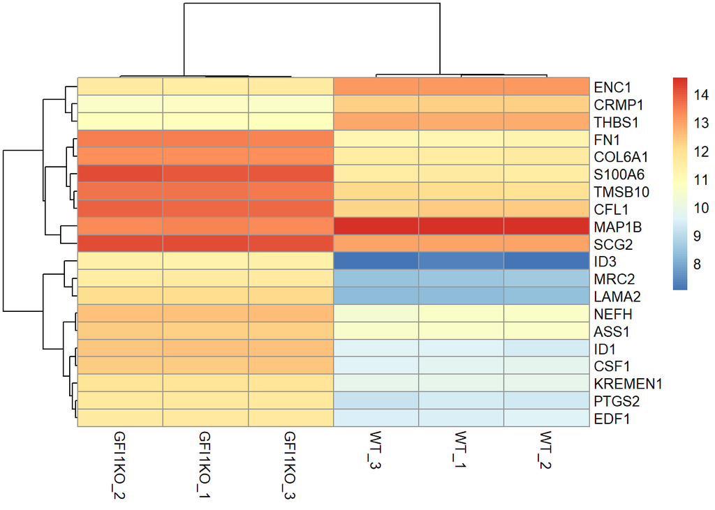

```r
pheatmap(log2(top_20 + 1))
```

## Gene Ontology and KEGG Pathway

Functional enrichment analysis is used to interpret gene expression results.

### Gene Ontology Enrichment

Filter significantly expressed genes for enrichment analysis.

```r
res_go <- res_df %>%
  filter(significant == "yes")
```

Create gene list for enrichment analysis.

```r
gene_list <- rownames(res_go)
```

#### Biological Process Ontology Analysis

Perform Gene Ontology enrichment analysis for Biological Process terms.

```r
ego1 <- enrichGO(gene=gene_list,
                 OrgDb = "org.Hs.eg.db",
                 keyType = "ENSEMBL",
                 ont = "BP",
                 readable = T)
```

Visualize Biological Process enrichment results.

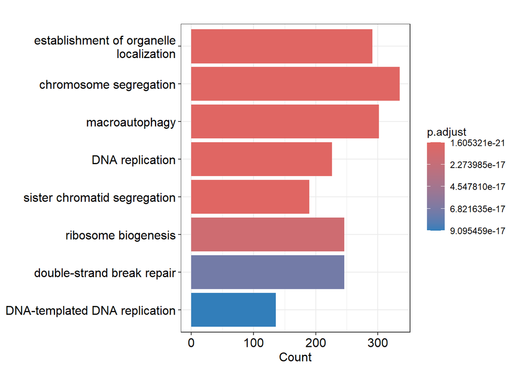

```r
barplot(ego1)
```

#### Molecular Function Ontology Analysis

Perform Gene Ontology enrichment analysis for Molecular Function terms.

```r
ego2 <- enrichGO(gene=gene_list,
                 OrgDb = "org.Hs.eg.db",
                 keyType = "ENSEMBL",
                 ont = "MF",
                 readable = T)
```

Visualize Molecular Function enrichment results.

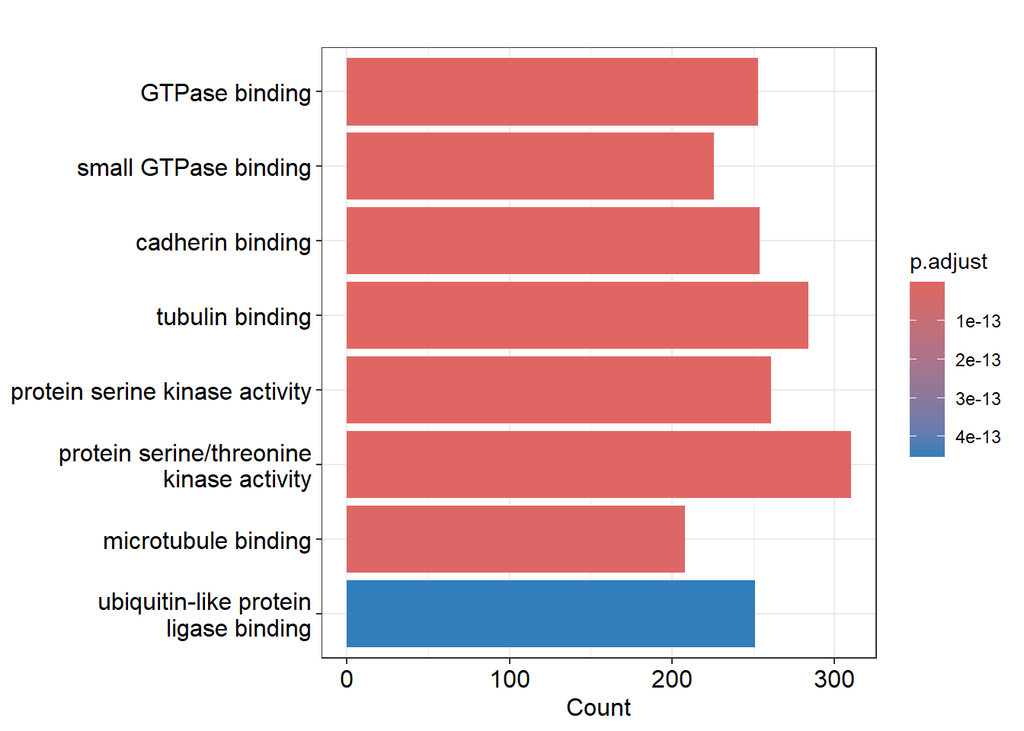

```r
barplot(ego2)
```

#### Cellular Component Ontology Analysis

Perform Gene Ontology enrichment analysis for Cellular Component terms.

```r
ego3 <- enrichGO(gene=gene_list,
                 OrgDb = "org.Hs.eg.db",
                 keyType = "ENSEMBL",
                 ont = "CC",
                 readable = T)
```

Visualize Cellular Component enrichment results.

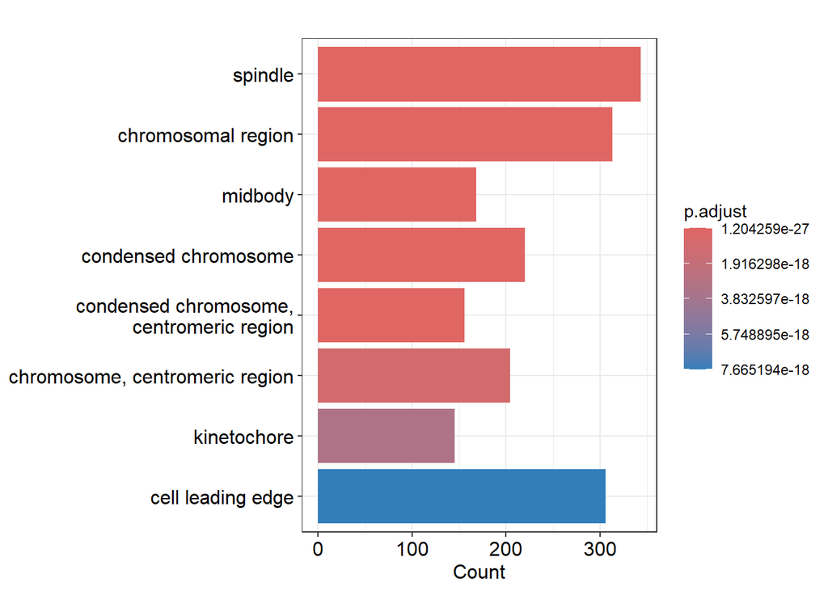

```r
ego3_plot <- barplot(ego3)
ego3_plot
```

Save Cellular Component enrichment plot.

```r
png("ego3_plot.png", width = 1200, height = 600, res = 150)
print(ego3_plot)
dev.off()
```

Visualize GO term-gene relationships using goplot().

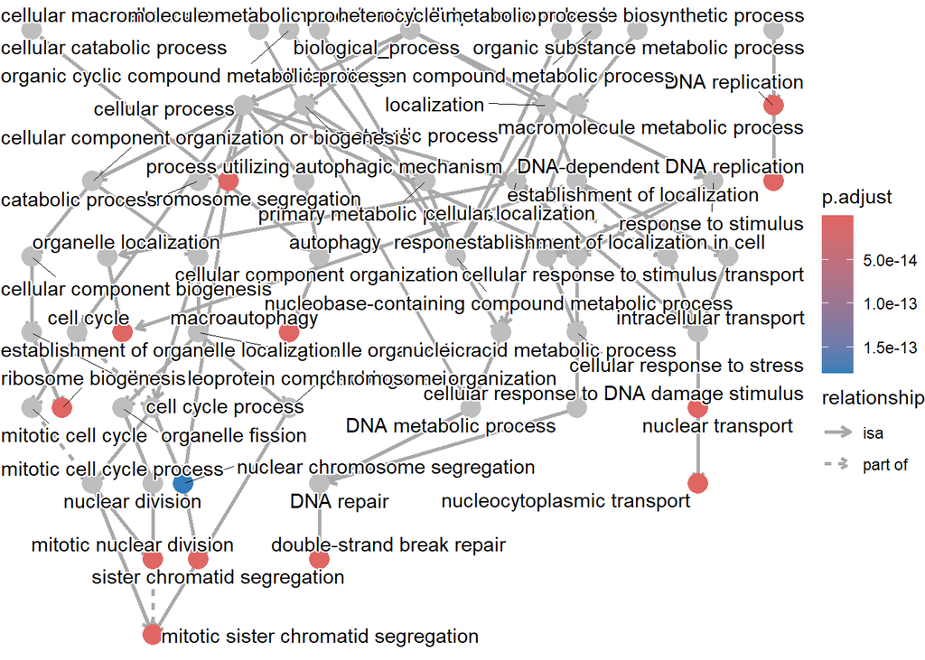

```r
options(ggrepel.max.overlaps = Inf)
goplot(ego1)
```

### KEGG Pathway Enrichment Analysis

Search for Homo sapiens organism information in KEGG.

```r
search <- search_kegg_organism("Homo sapiens")

search
```

```
##   kegg_code scientific_name common_name
## 1       hsa    Homo sapiens       human
```

Map ENSEMBL IDs to UniProt IDs.

```r
res_go$uniprot <- mapIds(org.Hs.eg.db,
                         keys = rownames(res_go),
                         keytype = "ENSEMBL",
                         column = "UNIPROT")
```

Store UniProt IDs for KEGG analysis.

```r
uniprot_id <- res_go$uniprot
```

Perform KEGG pathway enrichment analysis.

```r
kegg_enrich <- enrichKEGG(gene = uniprot_id,
                          organism = "hsa",
                          keyType = "uniprot")
```

```
## Reading KEGG annotation online: "https://rest.kegg.jp/link/hsa/pathway"...
```

```
## Reading KEGG annotation online: "https://rest.kegg.jp/list/pathway/hsa"...
```

```
## Reading KEGG annotation online: "https://rest.kegg.jp/conv/uniprot/hsa"...
```

```r
head(kegg_enrich)
```

```
##  [1] category       subcategory    ID             Description    GeneRatio
##  [6] BgRatio        RichFactor     FoldEnrichment zScore         pvalue
## [11] p.adjust       qvalue         geneID         Count
## <0 rows> (or 0-length row.names)
```

Display KEGG enrichment results.

```r
browseKEGG(kegg_enrich, "hsa03008")
```

Open KEGG pathway visualization in browser.

Visualize KEGG pathway using pathview().

```r
hsa03008 <- pathview(gene.data = uniprot_id,
                     species = "hsa",
                     pathway.id = "hsa03008",
                     gene.idtype = "uniprot")
```

```
## Info: Downloading xml files for hsa03008, 1/1 pathways..
```

```
## Info: Downloading png files for hsa03008, 1/1 pathways..
```

```
## Info: Working in directory C:/Users/User/Desktop/RNASeq_Project/Example-2/RNA Seq Data Analysis with GEO
```

```
## Info: Writing image file hsa03008.pathview.png
```